# Big Mart Sales prediction

## Problem statement

The data scientists at BigMart have collected 2013 sales data for 1559 products across 10 stores in different cities. Also, certain attributes of each product and store have been defined. The aim is to build a predictive model and find out the sales of each product at a particular store. Using this model, BigMart will try to understand the properties of products and stores which play a key role in increasing sales.

## Data

Train data set: 8523

Test data set: 5681

| Item_Identifier | Unique product ID |
| --- | --- |
| Item_Weight | Weight of product |
| Item_Fat_Content | Whether the product is low fat or not |
| Item_Visibility | The % of total display area of all products in a store allocated to the particular product |
| Item_Type | The category to which the product belongs |
| Item_MRP | Maximum Retail Price (list price) of the product |
| Outlet_Identifier | Unique store ID |
| Outlet_Establishment_Year | The year in which store was established |
| Outlet_Size | The size of the store in terms of ground area covered |
| Outlet_Location_Type | The type of city in which the store is located |
| Outlet_Type | Whether the outlet is just a grocery store or some sort of supermarket |
| Item_Outlet_Sales | Sales of the product in the particulat store. This is the outcome variable to be predicted. |

# Hypotheses generation

### Store Level Hypotheses

| Hypotheses name | Description | Variable |
| --- | --- | --- |
| Population Density | Stores located in densely populated areas should have higher sales because of more demand | N/A |
| Store Capacity | Stores which are very big in size should have higher sales as they act like one-stop-shops and people would prefer getting everything from one place | outlet_size / outlet_type |
| Store location | Stores located in urban cities should have higher sales because of the higher income levels of people there. Stores that are in neighbourhoods that are recidential or where there are many offices will… | outlet_location_type |
| Store age | Stores that have been in the same place for a very long time may have higher sales because personal relationships with local costumers have been built | outlet_stablishment_year |
| Store maintenance | Stores which are well-maintained and managed by polite and humble people are expected to have higher footfall and thus higher sales | N/A |
| Competitors | Stores having similar establishments nearby should have less sales because of more competition | N/A |

### Product Level Hypotheses

| Hypotheses name | Description | Variable |
| --- | --- | --- |
| Utility | Daily use products should have a higher tendency to sell as compared to the specific use products. Also products such are ready-made-meals, fruits and snacks | item_type/item_weight?/item_fat_content? |
| Display Area and visibility | Products which are given bigger shelves in the store, probably towards the entrance, are likely to catch attention first and sell more | item_visibility |
| Advertising | Better advertising of products in the store will should higher sales in most cases | N/A |
| Promotional Offers | Products accompanied with attractive offers and discounts will sell more | N/A |

## By: Divya Ray

# Understand the data

```python
import pandas as pd
import numpy as np
import matplotlib.pyplot as plt
import seaborn as sns
%matplotlib inline

train = pd.read_csv('/Users/Documents/github/data_science_projects_editing/MartSales/competition_data/Train_UWu5bXk.csv')
test = pd.read_csv('/Users/Documents/github/data_science_projects_editing/MartSales/competition_data/Test_u94Q5KV.csv')

train['source'] = 'train'
test['source'] = 'test'
data = pd.concat([train, test], ignore_index=True)
data.head()
```

|  | Item_Fat_Content | Item_Identifier | Item_MRP | Item_Outlet_Sales | Item_Type | Item_Visibility | Item_Weight | Outlet_Establishment_Year | Outlet_Identifier | Outlet_Location_Type | Outlet_Size | Outlet_Type | source |
| --- | --- | --- | --- | --- | --- | --- | --- | --- | --- | --- | --- | --- | --- |
| 0 | Low Fat | FDA15 | 249.8092 | 3735.1380 | Dairy | 0.016047 | 9.30 | 1999 | OUT049 | Tier 1 | Medium | Supermarket Type1 | train |
| 1 | Regular | DRC01 | 48.2692 | 443.4228 | Soft Drinks | 0.019278 | 5.92 | 2009 | OUT018 | Tier 3 | Medium | Supermarket Type2 | train |
| 2 | Low Fat | FDN15 | 141.6180 | 2097.2700 | Meat | 0.016760 | 17.50 | 1999 | OUT049 | Tier 1 | Medium | Supermarket Type1 | train |
| 3 | Regular | FDX07 | 182.0950 | 732.3800 | Fruits and Vegetables | 0.000000 | 19.20 | 1998 | OUT010 | Tier 3 | NaN | Grocery Store | train |
| 4 | Low Fat | NCD19 | 53.8614 | 994.7052 | Household | 0.000000 | 8.93 | 1987 | OUT013 | Tier 3 | High | Supermarket Type1 | train |

```python
data.info()
```

```
<class 'pandas.core.frame.DataFrame'>
RangeIndex: 14204 entries, 0 to 14203
Data columns (total 13 columns):
Item_Fat_Content             14204 non-null object
Item_Identifier              14204 non-null object
Item_MRP                     14204 non-null float64
Item_Outlet_Sales            8523 non-null float64
Item_Type                    14204 non-null object
Item_Visibility              14204 non-null float64
Item_Weight                  11765 non-null float64
Outlet_Establishment_Year    14204 non-null int64
Outlet_Identifier            14204 non-null object
Outlet_Location_Type         14204 non-null object
Outlet_Size                  10188 non-null object
Outlet_Type                  14204 non-null object
source                       14204 non-null object
dtypes: float64(4), int64(1), object(8)
memory usage: 1.4+ MB
```

```python
data.apply(lambda x: sum(x.isnull()))
```

```
Item_Fat_Content                0
Item_Identifier                 0
Item_MRP                        0
Item_Outlet_Sales            5681
Item_Type                       0
Item_Visibility                 0
Item_Weight                  2439
Outlet_Establishment_Year       0
Outlet_Identifier               0
Outlet_Location_Type            0
Outlet_Size                  4016
Outlet_Type                     0
source                          0
dtype: int64
```

Observations:

1. The missing values of the Item_Outlet_Sales come from the test dataset.
2. The missing values of Item_Weight and Outlet_Size need to be imputed.

```python
data.describe()
```

|  | Item_MRP | Item_Outlet_Sales | Item_Visibility | Item_Weight | Outlet_Establishment_Year |
| --- | --- | --- | --- | --- | --- |
| count | 14204.000000 | 8523.000000 | 14204.000000 | 11765.000000 | 14204.000000 |
| mean | 141.004977 | 2181.288914 | 0.065953 | 12.792854 | 1997.830681 |
| std | 62.086938 | 1706.499616 | 0.051459 | 4.652502 | 8.371664 |
| min | 31.290000 | 33.290000 | 0.000000 | 4.555000 | 1985.000000 |
| 25% | 94.012000 | 834.247400 | 0.027036 | 8.710000 | 1987.000000 |
| 50% | 142.247000 | 1794.331000 | 0.054021 | 12.600000 | 1999.000000 |
| 75% | 185.855600 | 3101.296400 | 0.094037 | 16.750000 | 2004.000000 |
| max | 266.888400 | 13086.964800 | 0.328391 | 21.350000 | 2009.000000 |

Observations:

1. The min value of Item_Visibility is 0, but this can not be as every item must have some visibility.
2. It might be more helpful to convert the Outlet_Establishment_Years into how old the establishments are.

```python
data.apply(lambda x: len(x.unique()))
```

```
Item_Fat_Content                 5
Item_Identifier               1559
Item_MRP                      8052
Item_Outlet_Sales             3494
Item_Type                       16
Item_Visibility              13006
Item_Weight                    416
Outlet_Establishment_Year        9
Outlet_Identifier               10
Outlet_Location_Type             3
Outlet_Size                      4
Outlet_Type                      4
source                           2
dtype: int64
```

Observations:

1. There are 1559 products - This is too many to be useful, we need to see how we can categorise them into a smaller number of groups
2. There are 10 stores.
3. Since the Item_MRP is bigger than the number of products, this could mean that in different stores, the MRP could be different.
4. There are only 16 Item_Type.

```python
# check out the frequecy of each different category in each nomical value

# filter the categorical variables
categorical_columns = [x for x in data.dtypes.index if data.dtypes[x]=='object']

# exclude the id and source columns
categorical_columns = [x for x in categorical_columns if x not in ['Item_Identifier', 'source']]

# print the frequency of categories
for col in categorical_columns:
    print('\nFrequency of Categories for variable %s'%(col))
    print(data[col].value_counts())
```

```
Frequency of Categories for variable Item_Fat_Content
Low Fat    8485
Regular    4824
LF          522
reg         195
low fat     178
Name: Item_Fat_Content, dtype: int64

Frequency of Categories for variable Item_Type
Fruits and Vegetables    2013
Snack Foods              1989
Household                1548
Frozen Foods             1426
Dairy                    1136
Baking Goods             1086
Canned                   1084
Health and Hygiene        858
Meat                      736
Soft Drinks               726
Breads                    416
Hard Drinks               362
Others                    280
Starchy Foods             269
Breakfast                 186
Seafood                    89
Name: Item_Type, dtype: int64

Frequency of Categories for variable Outlet_Identifier
OUT027    1559
OUT013    1553
OUT046    1550
OUT035    1550
OUT049    1550
OUT045    1548
OUT018    1546
OUT017    1543
OUT010     925
OUT019     880
Name: Outlet_Identifier, dtype: int64

Frequency of Categories for variable Outlet_Location_Type
Tier 3    5583
Tier 2    4641
Tier 1    3980
Name: Outlet_Location_Type, dtype: int64

Frequency of Categories for variable Outlet_Size
Medium    4655
Small     3980
High      1553
Name: Outlet_Size, dtype: int64

Frequency of Categories for variable Outlet_Type
Supermarket Type1    9294
Grocery Store        1805
Supermarket Type3    1559
Supermarket Type2    1546
Name: Outlet_Type, dtype: int64
```

Observations:

1. Low Fat, low fat and LF are all Low Fat; reg and Regular are both Regular.
2. Maybe combine some of the categories in Outlet_Type -> check the mean sales by type of outlet.
3. Stores with Outlet_Identifier OUT010 and OUT019 have significantly smaller number of sales.

#### Observations on Missing Values

1. The missing values of the Item_Outlet_Sales come from the test dataset.
2. The missing values of Item_Weight and Outlet_Size need to be imputed
3. The min value of Item_Visibility is 0, but this can not be as every item must have some visibility.
4. Low Fat, low fat and LF are all Low Fat; reg and Regular are both Regular.

#### Observations on Data Analysis to be done

1. There are 10 stores.
2. Since the Item_MRP is bigger than the number of products, this could mean that in different stores, the MRP could be different.
3. There are only 16 Item_Type.
4. Stores with Outlet_Identifier OUT010 and OUT019 have significantly smaller number of sales.

#### Observations on Feature engineering to be done

1. It might be more helpful to convert the Outlet_Establishment_Years into how old the establishments are.
2. There are 1559 products - This is too many to be useful, we need to see how we can categorise them into a smaller number of groups
3. Maybe combine some of the categories in Outlet_Type -> check the mean sales by type of outlet.

## Impute missing values

### Item_Weight

Assuming each Item_Identifier identifies a specific item, then it seems reasonable to impute the missing values of the Item_Weight by the average Item_Weight of each Item_Identifier.

To check that we have imputed the values in a reasonable way, we can check the average weight per Outlet_Identifier before and after imputing the missing values.

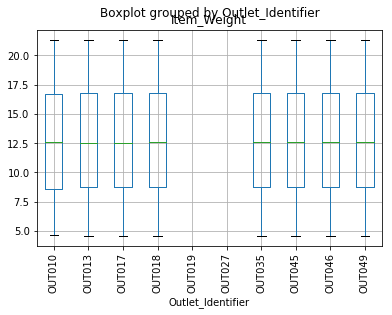

```python
data.boxplot(column='Item_Weight', by='Outlet_Identifier', rot=90)
```

This graph shows that the missing weight affects two outlets.

```python
# average weight per item
item_av_weight = data.pivot_table(values='Item_Weight', index='Item_Identifier')
item_av_weight.head()
```

| Item_Identifier | Item_Weight |
| --- | --- |
| DRA12 | 11.600 |
| DRA24 | 19.350 |
| DRA59 | 8.270 |
| DRB01 | 7.390 |
| DRB13 | 6.115 |

```python
# create a mask of the missing data in Item_Weight
null_mask_weight = data['Item_Weight'].isnull()

# impute values
data.loc[null_mask_weight, 'Item_Weight'] = data.loc[null_mask_weight, 'Item_Identifier'].apply(lambda x: item_av_weight.loc[x])
```

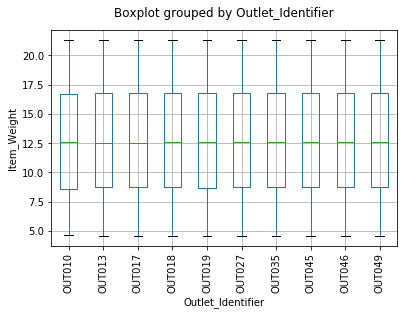

```python
ax = data.boxplot(column='Item_Weight', by='Outlet_Identifier', rot=90)
ax.set_ylabel('Item_Weight')
ax.set_title('')
```

And now we can see that the values we have chosen to replace the missing weights are reasonable as the boxplot of the affected outlets now follows the same pattern as the others.

### Outlet_Size

It could be reasonable to impute the missing values of Outlet_size by the mode size for each Outlet_Type.

Let's have a look at the mode size for each Outlet_Type.

```python
from scipy.stats import mode

# replace all nan values with 'unknown', because the mode function of stats can not compare a float (NaN) and a string
data['Outlet_Size'] = data['Outlet_Size'].fillna('unknown')

# mode size per Outlet_Type
outlet_type_mode_size = data.pivot_table(values='Outlet_Size', index='Outlet_Type', aggfunc=(lambda x:mode(x).mode[0]))
outlet_type_mode_size
```

| Outlet_Type | Outlet_Size |
| --- | --- |
| Grocery Store | unknown |
| Supermarket Type1 | Small |
| Supermarket Type2 | Medium |
| Supermarket Type3 | Medium |

Grocery stores could be considered to be smaller than the supermarkets, so we could replace the 'unknown' in the pivot table above by 'small', but let's check the the sales in each Outlet_Type to see if we can confirm this.

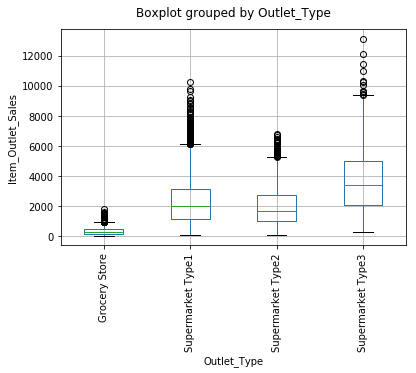

```python
# sales per Outlet_Type
ax = data.boxplot(column='Item_Outlet_Sales', by='Outlet_Type', rot=90)
ax.set_ylabel('Item_Outlet_Sales')
ax.set_title('')
```

```
[Text(0, 0, 'Grocery Store'),
```

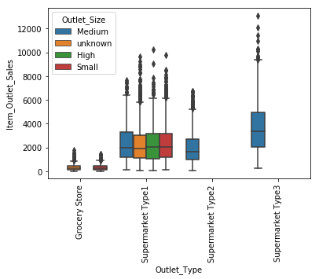

```python
import seaborn as sns
ax = sns.boxplot(data=data, x='Outlet_Type', y='Item_Outlet_Sales', hue='Outlet_Size', order=['Grocery Store', 'Supermarket Type1', 'Supermarket Type2', 'Supermarket Type3'])
ax.set_xticklabels(ax.get_xticklabels(),rotation=90)
#ax = data.boxplot(column='Item_Outlet_Sales', by=['Outlet_Type', 'Outlet_Size'], rot=90)
#ax.set_ylabel('Item_Outlet_Sales')
#ax.set_title('')
```

Grocery stores report far fewer sales than the other Outlet_Types and they have Outlet_Size values that are either 'small' or 'unknown'. Therefore we can reasonably replace the mode value of Grocery Stores with 'small' and impute the missing values of Outlet_Size with the mode value for each Outlet_Type. To check we have done this correctly, we can visualise the Item_Outlet_Sales per Outlet_Identifier.

Note also that Type 2 stores are all medium and Type 3 are also all medium size. Type 1 stores have all sizes, which all have similar sales.

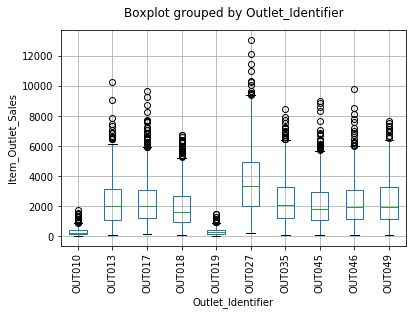

```python
# sales per Outlet_Identifier
ax = data.boxplot(column='Item_Outlet_Sales', by='Outlet_Identifier', rot=90)
ax.set_ylabel('Item_Outlet_Sales')
ax.set_title('')
```

OUT010 and OUT019 seem to be of size 'small'.

```python
# print Outlet_Type of OUT010 and Out019
outlet_identifier_mode_size = data.pivot_table(values='Outlet_Size', index='Outlet_Identifier', aggfunc=(lambda x:mode(x).mode[0]))
outlet_identifier_mode_size
```

| Outlet_Identifier | Outlet_Size |
| --- | --- |
| OUT010 | unknown |
| OUT013 | High |
| OUT017 | unknown |
| OUT018 | Medium |
| OUT019 | Small |
| OUT027 | Medium |
| OUT035 | Small |
| OUT045 | unknown |
| OUT046 | Small |
| OUT049 | Medium |

So OUT010 is unknown; after imputing missing values it should be 'small'.

```python
# replace the Outlet_Size of the Grocery Store in the pivot table with small
outlet_type_mode_size.loc['Grocery Store'] = 'Small'
outlet_type_mode_size
```

| Outlet_Type | Outlet_Size |
| --- | --- |
| Grocery Store | Small |
| Supermarket Type1 | Small |
| Supermarket Type2 | Medium |
| Supermarket Type3 | Medium |

```python
# create a mask of the missing data in Item_Weight
null_mask_size = data['Outlet_Size']=='unknown'

# impute values
data.loc[null_mask_size, 'Outlet_Size'] = data.loc[null_mask_size, 'Outlet_Type'].apply(lambda x: outlet_type_mode_size.loc[x])

# check no missing values
#print(data['Outlet_Size'].head(10))
#print(data.info())
```

```python
# print Outlet_Type of OUT010 and Out019
outlet_identifier_mode_size = data.pivot_table(values='Outlet_Size', index='Outlet_Identifier', aggfunc=(lambda x:mode(x).mode[0]))
outlet_identifier_mode_size
```

| Outlet_Identifier | Outlet_Size |
| --- | --- |
| OUT010 | Small |
| OUT013 | High |
| OUT017 | Small |
| OUT018 | Medium |
| OUT019 | Small |
| OUT027 | Medium |
| OUT035 | Small |
| OUT045 | Small |
| OUT046 | Small |
| OUT049 | Medium |

```python
data.pivot_table(values='Outlet_Type', index='Outlet_Identifier', aggfunc=(lambda x:mode(x).mode[0]))
```

| Outlet_Identifier | Outlet_Type |
| --- | --- |
| OUT010 | Grocery Store |
| OUT013 | Supermarket Type1 |
| OUT017 | Supermarket Type1 |
| OUT018 | Supermarket Type2 |
| OUT019 | Grocery Store |
| OUT027 | Supermarket Type3 |
| OUT035 | Supermarket Type1 |
| OUT045 | Supermarket Type1 |
| OUT046 | Supermarket Type1 |
| OUT049 | Supermarket Type1 |

It is reasonable that OUT017 and OUT045 are imputed with small because their mode Outlet_Type is Supermarket Type 1 which has mode Outlet_Size small.

### Min value of Item_Visibility

The min value of Item_Visibility is 0, but this can not be as every item must have some visibility.

We want to replace the 0 values for the mean visibility value of that product in each store.

```python
# check how many entries have 0
data['Item_Visibility'].value_counts().head()
```

```
0.000000    879
0.076856      3
0.076841      3
0.077290      3
0.077169      3
Name: Item_Visibility, dtype: int64
```

879 out of 14204 is a lot so we replace the 0 values for NAN values so the mean value is not affected.

```python
# visual check that the 0 values in the firs 10 entries have been replaced
data['Item_Visibility'] = data['Item_Visibility'].replace({0:np.nan})
```

Check the visibility for each Item_Type in each Outlet_Type.

```
[Text(0, 0, 'Dairy'),
```

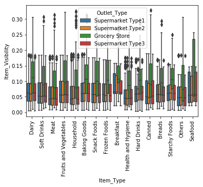

```python
ax = sns.boxplot(data=data, x='Item_Type', y='Item_Visibility', hue='Outlet_Type')
ax.set_xticklabels(ax.get_xticklabels(),rotation=90)
```

```python
data['Item_Visibility'].head(10)
```

```
0    0.016047
1    0.019278
2    0.016760
3         NaN
4         NaN
5         NaN
6    0.012741
7    0.127470
8    0.016687
9    0.094450
Name: Item_Visibility, dtype: float64
```

```python
# pivot table with the mean values that will be used to replace the nan values
table = data.pivot_table(values='Item_Visibility', index='Item_Type', columns='Outlet_Type', aggfunc='mean')
table
```

| Outlet_Type Item_Type | Grocery Store | Supermarket Type1 | Supermarket Type2 | Supermarket Type3 |
| --- | --- | --- | --- | --- |
| Baking Goods | 0.116306 | 0.066692 | 0.068206 | 0.066524 |
| Breads | 0.111612 | 0.067579 | 0.067976 | 0.066038 |
| Breakfast | 0.126056 | 0.079993 | 0.083079 | 0.078609 |
| Canned | 0.112484 | 0.066167 | 0.064655 | 0.067549 |
| Dairy | 0.120742 | 0.069299 | 0.069000 | 0.069213 |
| Frozen Foods | 0.115895 | 0.065449 | 0.064184 | 0.064816 |
| Fruits and Vegetables | 0.114820 | 0.067123 | 0.067503 | 0.066758 |
| Hard Drinks | 0.109913 | 0.064873 | 0.063611 | 0.065297 |
| Health and Hygiene | 0.098924 | 0.055021 | 0.053081 | 0.054924 |
| Household | 0.099288 | 0.057774 | 0.057858 | 0.057625 |
| Meat | 0.095960 | 0.058676 | 0.058574 | 0.058451 |
| Others | 0.096714 | 0.055688 | 0.056357 | 0.055413 |
| Seafood | 0.122593 | 0.067158 | 0.071047 | 0.075858 |
| Snack Foods | 0.114660 | 0.065578 | 0.065584 | 0.065126 |
| Soft Drinks | 0.108376 | 0.064303 | 0.064451 | 0.065485 |
| Starchy Foods | 0.117891 | 0.066730 | 0.068340 | 0.067608 |

```python
# replace the nan values
# define function that returns the mean values
def find_mean(x):
    return table.loc[x['Item_Type'], x['Outlet_Type']]

# replace missing values in loan_amount with median values
data['Item_Visibility'].fillna(data[data['Item_Visibility'].isnull()].apply(find_mean, axis=1), inplace=True)
```

```
[Text(0, 0, 'Dairy'),
```

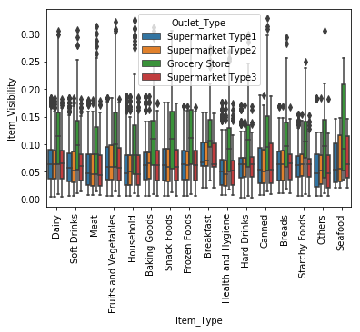

```python
ax = sns.boxplot(data=data, x='Item_Type', y='Item_Visibility', hue='Outlet_Type')
ax.set_xticklabels(ax.get_xticklabels(),rotation=90)
```

```python
data['Item_Visibility'].head(10)
```

```
0    0.016047
1    0.019278
2    0.016760
3    0.114820
4    0.057774
5    0.068206
6    0.012741
7    0.127470
8    0.016687
9    0.094450
Name: Item_Visibility, dtype: float64
```

### Combine Low Fat, low fat and LF to Low Fat and reg and Regular to Regular

```python
data['Item_Fat_Content'] = data['Item_Fat_Content'].replace({'LF': 'Low Fat',
                                                             'low fat': 'Low Fat',
                                                             'reg': 'Regular'})
data['Item_Fat_Content'].head(5)
```

```
0    Low Fat
1    Regular
2    Low Fat
3    Regular
4    Low Fat
Name: Item_Fat_Content, dtype: object
```

```python
print('\nFrequency of Categories for variable Item_Fat_Content')
print(data['Item_Fat_Content'].value_counts())
```

```
Frequency of Categories for variable Item_Fat_Content
Low Fat    9185
Regular    5019
Name: Item_Fat_Content, dtype: int64
```

## Feature Engineering

### Convert the Outlet_Establishment_Years into how old the establishments are

```python
data['Outlet_Age'] = 2013 - data['Outlet_Establishment_Year']
data['Outlet_Age'].head(5)
```

```
0    14
1     4
2    14
3    15
4    26
Name: Outlet_Age, dtype: int64
```

```python
data['Outlet_Age'].describe()
```

```
count    14204.000000
mean        15.169319
std          8.371664
min          4.000000
25%          9.000000
50%         14.000000
75%         26.000000
max         28.000000
Name: Outlet_Age, dtype: float64
```

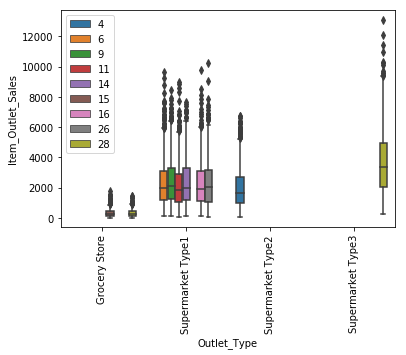

```python
ax = sns.boxplot(data=data, x='Outlet_Type', y='Item_Outlet_Sales', hue='Outlet_Age', order=['Grocery Store', 'Supermarket Type1', 'Supermarket Type2', 'Supermarket Type3'])
ax.set_xticklabels(ax.get_xticklabels(),rotation=90)
leg = ax.legend()
ax.legend(loc='upper left')
```

Supermarket type 3 is the oldest, having been stablished 28 years ago. Type 1 have been build at different times, Type 2 is the newest. Grocery stores are relaviely old.

### Create broader category for type of item

Notice the Item_Identifiers all start with letters. Let's see what they are and what they mean.

```python
data['Item_Type_Category'] = data['Item_Identifier'].astype(str).str[:3]
data['Item_Type_Category'].unique()
```

```
array(['FDA', 'DRC', 'FDN', 'FDX', 'NCD', 'FDP', 'FDO', 'FDH', 'FDU',
       'FDY', 'FDS', 'FDF', 'NCB', 'DRI', 'FDW', 'FDC', 'FDR', 'FDV',
       'DRJ', 'FDE', 'NCS', 'DRH', 'NCX', 'DRZ', 'FDB', 'FDK', 'FDL',
       'FDM', 'NCP', 'NCL', 'DRK', 'FDI', 'FDZ', 'NCI', 'FDJ', 'FDG',
       'NCZ', 'FDQ', 'FDD', 'DRG', 'NCR', 'FDT', 'DRB', 'DRE', 'DRA',
       'NCF', 'NCH', 'NCO', 'NCN', 'NCC', 'DRD', 'DRF', 'DRL', 'NCM',
       'NCU', 'DRY', 'NCW', 'DRM', 'NCT', 'NCQ', 'DRP', 'DRQ', 'NCK',
       'NCY', 'DRN', 'NCA', 'NCE', 'NCJ', 'NCV', 'NCG', 'DRO'],
      dtype=object)
```

These seem to stand for Food, Drink and Non-Consumable. So rename them to be more intuitive.

```python
data['Item_Type_Category'] = data['Item_Identifier'].astype(str).str[:2]
data['Item_Type_Category'].unique()
```

```
array(['FD', 'DR', 'NC'], dtype=object)
```

```python
data['Item_Type_Category'] = data['Item_Type_Category'].map({'FD': 'Food', 'DR':'Drink', 'NC':'Non-Consumable'})
```

```python
data['Item_Type_Category'].value_counts()
```

```
Food              10201
Non-Consumable     2686
Drink              1317
Name: Item_Type_Category, dtype: int64
```

### Change value of the 'Item_Fat_Content' of the items that are non-consumables.

Non-consumables do not have a fat content.

```python
data.loc[data['Item_Type_Category']=='Non-Consumable', 'Item_Fat_Content'] = 'Non-Edible'
data['Item_Fat_Content'].value_counts()
```

```
Low Fat       6499
Regular       5019
Non-Edible    2686
Name: Item_Fat_Content, dtype: int64
```

### Make a new category for items that reflect their sales - very high, high, medium, low.

Recall that there are more Item_RMP than Item_Identifier, indicating that different stores have different Item_MRP. We can visualise the Item_RMP grouped by the Item_Type and Outlet_Type

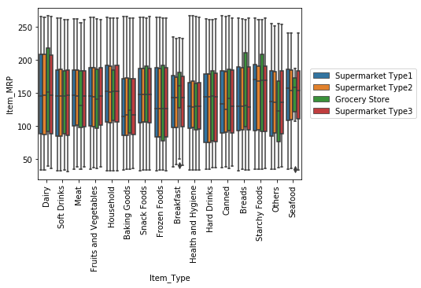

```python
ax = sns.boxplot(data=data, x='Item_Type', y='Item_MRP', hue='Outlet_Type')
ax.set_xticklabels(ax.get_xticklabels(),rotation=90)
leg = ax.legend()
ax.legend(loc='center right', bbox_to_anchor=(1.45, 0.5))
```

All the Item_Types seems to have a similar average Item_MRP accross the Outlet_Types. So we do not need to consider different Item_MRP per Outlet_Type.

Now we can have a look at the distribution of all Item_MRP.

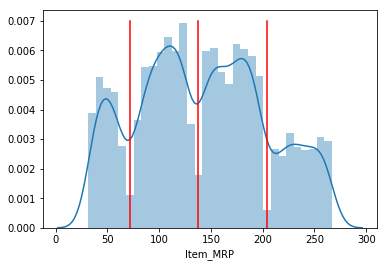

```python
ax = sns.distplot(data['Item_MRP'])
x1=72
x2=138
x3=204
ax.plot([x1, x1],[0, 0.007], color='r')
ax.plot([x2, x2],[0, 0.007],color='r')
ax.plot([x3, x3],[0, 0.007],color='r')
plt.show()
```

The Item_MRP clearly shows there are 4 different price categories. So we define them to be 'Low', 'Medium', 'High', 'Very High'.

```python
def price_cat(x):
    if x <= x1:
        return 'Low'
    elif (x > x1) & (x <= x2):
        return 'Medium'
    elif (x > x2) & (x <= x3):
        return 'High'
    else:
        return 'Very High'

data['Item_MRP_Category'] = data['Item_MRP']
data['Item_MRP_Category'] = data['Item_MRP_Category'].apply(price_cat)
data['Item_MRP_Category'].value_counts()
```

```
High         4934
Medium       4659
Very High    2400
Low          2211
Name: Item_MRP_Category, dtype: int64
```

## Analysis

### Numerical data

```python
data.describe()
```

|  | Item_MRP | Item_Outlet_Sales | Item_Visibility | Item_Weight | Outlet_Establishment_Year | Outlet_Age |
| --- | --- | --- | --- | --- | --- | --- |
| count | 14204.000000 | 8523.000000 | 14204.000000 | 14204.000000 | 14204.000000 | 14204.000000 |
| mean | 141.004977 | 2181.288914 | 0.070270 | 12.793380 | 1997.830681 | 15.169319 |
| std | 62.086938 | 1706.499616 | 0.048750 | 4.651716 | 8.371664 | 8.371664 |
| min | 31.290000 | 33.290000 | 0.003575 | 4.555000 | 1985.000000 | 4.000000 |
| 25% | 94.012000 | 834.247400 | 0.033143 | 8.710000 | 1987.000000 | 9.000000 |
| 50% | 142.247000 | 1794.331000 | 0.060322 | 12.600000 | 1999.000000 | 14.000000 |
| 75% | 185.855600 | 3101.296400 | 0.095967 | 16.750000 | 2004.000000 | 26.000000 |
| max | 266.888400 | 13086.964800 | 0.328391 | 21.350000 | 2009.000000 | 28.000000 |

#### Item_MRP

As we have seen previously, the Item_MRP is clearly divided into 4 categories. Now, let's plot the Item_MRP grouped by the Outlet_Type and Outle_Size.

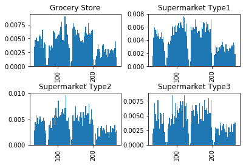

```python
ax = data.hist(column='Item_MRP' , by='Outlet_Type', bins=100, density=True)
```

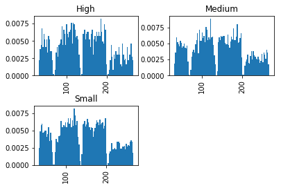

```python
ax = data.hist(column='Item_MRP' , by='Outlet_Size', bins=100, density=True)
```

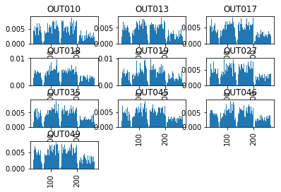

```python
ax = data.hist(column='Item_MRP' , by='Outlet_Identifier', bins=100, density=True)
```

So the different categories of Item_MRP are well represented accross all outlets.

Explore how Item_MRP depends on Outlet_Type:

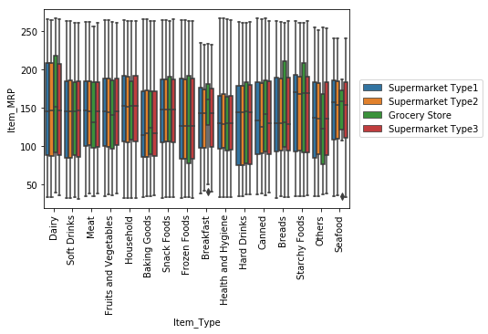

```python
ax = sns.boxplot(data=data, x='Item_Type', y='Item_MRP', hue='Outlet_Type')
ax.set_xticklabels(ax.get_xticklabels(),rotation=90)
leg = ax.legend()
ax.legend(loc='center right', bbox_to_anchor=(1.45, 0.5))
```

```
No handles with labels found to put in legend.
No handles with labels found to put in legend.
```

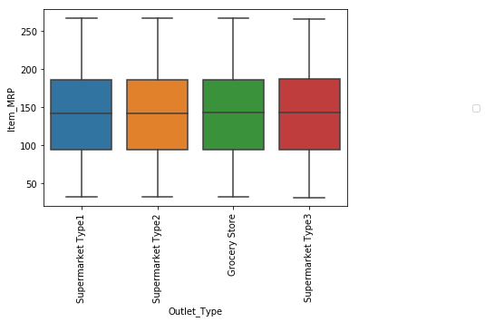

```python
ax = sns.boxplot(data=data, x='Outlet_Type', y='Item_MRP')
ax.set_xticklabels(ax.get_xticklabels(),rotation=90)
leg = ax.legend()
ax.legend(loc='center right', bbox_to_anchor=(1.45, 0.5))
```

Item_MRP does not differ depending on Outlet_Type.

#### Item_Outlet_Sales

```
No handles with labels found to put in legend.
No handles with labels found to put in legend.
```

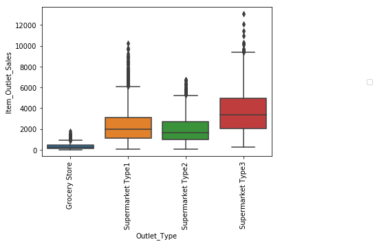

```python
ax = sns.boxplot(data=data, x='Outlet_Type', y='Item_Outlet_Sales', order=['Grocery Store', 'Supermarket Type1', 'Supermarket Type2', 'Supermarket Type3'])
ax.set_xticklabels(ax.get_xticklabels(),rotation=90)
leg = ax.legend()
ax.legend(loc='center right', bbox_to_anchor=(1.45, 0.5))
```

Item_Outlet_Sales are very low for Grocery Stores, even though we saw above the Item_MRP is the same for all Outlet_Types.

Let's Explore if this is because of the Outlet_Size.

```
[Text(0, 0, 'Grocery Store'),
```

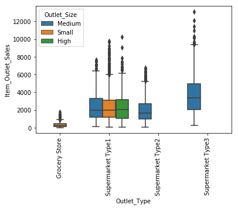

```python
# Item_Outlet_Sales per Outlet_Type and Outlet_Size
ax = sns.boxplot(data=data, x='Outlet_Type', y='Item_Outlet_Sales', hue='Outlet_Size', order=['Grocery Store', 'Supermarket Type1', 'Supermarket Type2', 'Supermarket Type3'])
ax.set_xticklabels(ax.get_xticklabels(),rotation=90)
```

No, it is just about the Grocery Stores. Let's explore how they Item_Types differ depending on Outlet_Type.

```
[Text(0, 0, 'Dairy'),
```

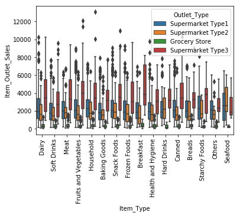

```python
ax = sns.boxplot(data=data, x='Item_Type', y='Item_Outlet_Sales', hue='Outlet_Type')
ax.set_xticklabels(ax.get_xticklabels(),rotation=90)
```

Grocery stores just sell a smaller number of everything.

```
[Text(0, 0, 'Grocery Store'),
```

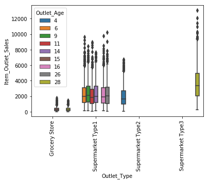

```python
# Item_Outlet_Sales per Outlet_Type and Outlet_Age
ax = sns.boxplot(data=data, x='Outlet_Type', y='Item_Outlet_Sales', hue='Outlet_Age', order=['Grocery Store', 'Supermarket Type1', 'Supermarket Type2', 'Supermarket Type3'])
ax.set_xticklabels(ax.get_xticklabels(),rotation=90)
```

Interestingly, type 3 supermarkets perform the best in pure sales (Item_Outlet_Sales), even though they are the oldest and they are also medium sized.

Now let's explore how each store (Outlet_Identifier) performs in sales:

```
[Text(0, 0, 'OUT049'),
```

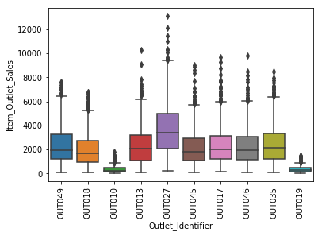

```python
# Item_Outlet_Sales per Outlet_Identifier
ax = sns.boxplot(data=data, x='Outlet_Identifier', y='Item_Outlet_Sales')
ax.set_xticklabels(ax.get_xticklabels(),rotation=90)
```

```python
for i in data['Outlet_Identifier'].unique():
    otype = data[data['Outlet_Identifier']==i]['Outlet_Type'].unique()
    osize = data[data['Outlet_Identifier']==i]['Outlet_Size'].unique()
    print('Outlet_Identifier: {}, Outlet_Type(s): {}, Outlet_Size: {}'.format(i, otype, osize))
```

```
Outlet_Identifier: OUT049, Outlet_Type(s): ['Supermarket Type1'], Outlet_Size: ['Medium']
Outlet_Identifier: OUT018, Outlet_Type(s): ['Supermarket Type2'], Outlet_Size: ['Medium']
Outlet_Identifier: OUT010, Outlet_Type(s): ['Grocery Store'], Outlet_Size: ['Small']
Outlet_Identifier: OUT013, Outlet_Type(s): ['Supermarket Type1'], Outlet_Size: ['High']
Outlet_Identifier: OUT027, Outlet_Type(s): ['Supermarket Type3'], Outlet_Size: ['Medium']
Outlet_Identifier: OUT045, Outlet_Type(s): ['Supermarket Type1'], Outlet_Size: ['Small']
Outlet_Identifier: OUT017, Outlet_Type(s): ['Supermarket Type1'], Outlet_Size: ['Small']
Outlet_Identifier: OUT046, Outlet_Type(s): ['Supermarket Type1'], Outlet_Size: ['Small']
Outlet_Identifier: OUT035, Outlet_Type(s): ['Supermarket Type1'], Outlet_Size: ['Small']
Outlet_Identifier: OUT019, Outlet_Type(s): ['Grocery Store'], Outlet_Size: ['Small']
```

Again, this confirms that low sales is due to the outlet being a grocery store and not because the size is small.

#### Item_Number_Sales

Given that the Item_MRP does not change significantly accross the stores, it might be more useful to analyse the number of items sold, not the Item_Outlet_Sales. The Item_Outlet_Sales is the number of items sold times the Item_MRP. So let's make a new variable with the number of items sold (by dividing the Item_Outlet_Sales by Item_MRP).

```python
data['Item_Number_Sales'] = data['Item_Outlet_Sales']/data['Item_MRP']
```

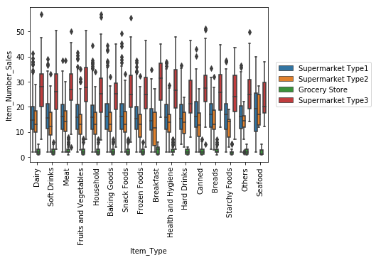

```python
ax = sns.boxplot(data=data, x='Item_Type', y='Item_Number_Sales', hue='Outlet_Type')
ax.set_xticklabels(ax.get_xticklabels(),rotation=90)
leg = ax.legend()
ax.legend(loc='center right', bbox_to_anchor=(1.45, 0.5))
```

```
No handles with labels found to put in legend.
No handles with labels found to put in legend.
```

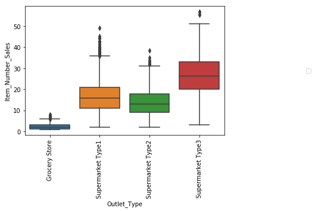

```python
ax = sns.boxplot(data=data, x='Outlet_Type', y='Item_Number_Sales', order=['Grocery Store', 'Supermarket Type1', 'Supermarket Type2', 'Supermarket Type3'])
ax.set_xticklabels(ax.get_xticklabels(),rotation=90)
leg = ax.legend()
ax.legend(loc='center right', bbox_to_anchor=(1.45, 0.5))
```

```
[Text(0, 0, 'Grocery Store'),
```

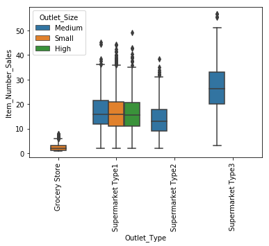

```python
# Item_Outlet_Sales per Outlet_Type and Outlet_Size
ax = sns.boxplot(data=data, x='Outlet_Type', y='Item_Number_Sales', hue='Outlet_Size', order=['Grocery Store', 'Supermarket Type1', 'Supermarket Type2', 'Supermarket Type3'])
ax.set_xticklabels(ax.get_xticklabels(),rotation=90)
```

```
[Text(0, 0, 'OUT049'),
```

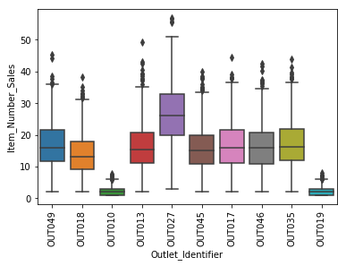

```python
# Item_Outlet_Sales per Outlet_Identifier
ax = sns.boxplot(data=data, x='Outlet_Identifier', y='Item_Number_Sales')
ax.set_xticklabels(ax.get_xticklabels(),rotation=90)
```

So it is clear that in pure numbers Grocery Stores sell less.

#### Item_outlet_sales and Item_MRP vs Item_Visibility

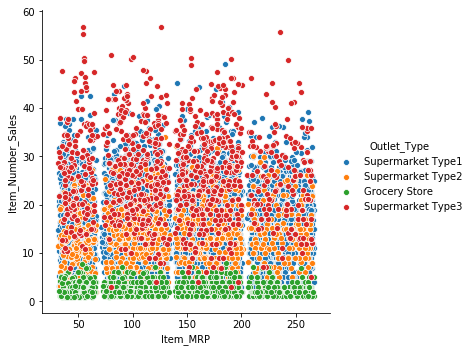

```python
sns.pairplot(data=data, x_vars='Item_MRP', y_vars='Item_Number_Sales', hue='Outlet_Type', size=5)
```

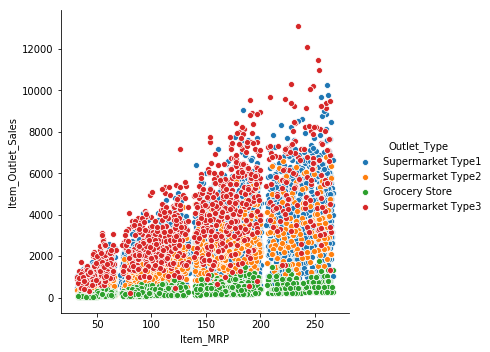

```python
sns.pairplot(data=data, x_vars='Item_MRP', y_vars='Item_Outlet_Sales', hue='Outlet_Type', size=5)
```

```python
cor1 = data['Item_MRP'].corr(data['Item_Outlet_Sales'])
cor2 = data['Item_MRP'].corr(data['Item_Number_Sales'])
print('Correlation between Item_MRP and Item_Outlet_Sales: {}'.format(cor1))
print('Correlation between Item_MRP and Item_Number_Sales: {}'.format(cor2))
```

```
Correlation between Item_MRP and Item_Outlet_Sales: 0.5675744466569193
Correlation between Item_MRP and Item_Number_Sales: 0.01114352701232483
```

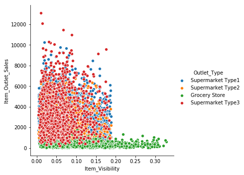

```python
sns.pairplot(data=data, x_vars='Item_Visibility', y_vars='Item_Outlet_Sales', hue='Outlet_Type', size=5)
```

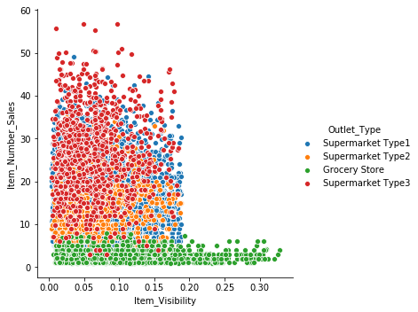

```python
sns.pairplot(data=data, x_vars='Item_Visibility', y_vars='Item_Number_Sales', hue='Outlet_Type', size=5)
```

```python
cor1 = data['Item_Visibility'].corr(data['Item_Outlet_Sales'])
cor2 = data['Item_Visibility'].corr(data['Item_Number_Sales'])
print('Correlation between Item_Visibility and Item_Outlet_Sales: {}'.format(cor1))
print('Correlation between Item_Visibility and Item_Number_Sales: {}'.format(cor2))
```

```
Correlation between Item_Visibility and Item_Outlet_Sales: -0.14076174687662235
Correlation between Item_Visibility and Item_Number_Sales: -0.17440844918045084
```

There is a positive correlation between Item_MRP and Item_Outlet_Sales and a negative correlation between Item_Outlet_Sales and visibility.

There is no correlation Item_MRP and Item_Number_Sales and there is a negative correlation between Item_Number_Sales and visibility.

Questions that arrise:

1. Why do Gorcery Stores have items with Item_Visibility at heights that do not appear at other outlet_types?

### Analysis of Categorical Data

```python
# check out the frequecy of each different category in each nomical value

# filter the categorical variables
categorical_columns = [x for x in data.dtypes.index if data.dtypes[x]=='object']

# exclude the id and source columns
categorical_columns = [x for x in categorical_columns if x not in ['Item_Identifier', 'source']]

# print the frequency of categories
for col in categorical_columns:
    print('\nFrequency of Categories for variable %s'%(col))
    print(data[col].value_counts())
```

```
Frequency of Categories for variable Item_Fat_Content
Low Fat       6499
Regular       5019
Non-Edible    2686
Name: Item_Fat_Content, dtype: int64

Frequency of Categories for variable Item_Type
Fruits and Vegetables    2013
Snack Foods              1989
Household                1548
Frozen Foods             1426
Dairy                    1136
Baking Goods             1086
Canned                   1084
Health and Hygiene        858
Meat                      736
Soft Drinks               726
Breads                    416
Hard Drinks               362
Others                    280
Starchy Foods             269
Breakfast                 186
Seafood                    89
Name: Item_Type, dtype: int64

Frequency of Categories for variable Outlet_Identifier
OUT027    1559
OUT013    1553
OUT046    1550
OUT035    1550
OUT049    1550
OUT045    1548
OUT018    1546
OUT017    1543
OUT010     925
OUT019     880
Name: Outlet_Identifier, dtype: int64

Frequency of Categories for variable Outlet_Location_Type
Tier 3    5583
```

[output cut: 14 more lines]

```
Supermarket Type2    1546
Name: Outlet_Type, dtype: int64

Frequency of Categories for variable Item_Type_Category
Food              10201
Non-Consumable     2686
Drink              1317
Name: Item_Type_Category, dtype: int64

Frequency of Categories for variable Item_MRP_Category
High         4934
Medium       4659
Very High    2400
Low          2211
Name: Item_MRP_Category, dtype: int64
```

## Numerical and One-Hot Coding of Categorical Variables

Some of the models we will use require only numerical data.

```python
data.to_csv('/Users/shusasaki/Documents/github/data_science_projects_editing/MartSales/modified_data/data.csv', index=False)
```

```python
# drop the Outlet_Establishment_Year and Item_Number_Sales columns from the data
data = data.drop(['Outlet_Establishment_Year','Item_Number_Sales'], axis=1)
data.dtypes
```

```
Item_Fat_Content         object
Item_Identifier          object
Item_MRP                float64
Item_Outlet_Sales       float64
Item_Type                object
Item_Visibility         float64
Item_Weight             float64
Outlet_Identifier        object
Outlet_Location_Type     object
Outlet_Size              object
Outlet_Type              object
source                   object
Outlet_Age                int64
Item_Type_Category       object
Item_MRP_Category        object
dtype: object
```

```python
data.columns
```

```
Index(['Item_Fat_Content', 'Item_Identifier', 'Item_MRP', 'Item_Outlet_Sales',
       'Item_Type', 'Item_Visibility', 'Item_Weight', 'Outlet_Identifier',
       'Outlet_Location_Type', 'Outlet_Size', 'Outlet_Type', 'source',
       'Outlet_Age', 'Item_Type_Category', 'Item_MRP_Category'],
      dtype='object')
```

```python
from copy import deepcopy
data_copy = deepcopy(data)
```

### Numerical Coding of Categorical Data

```python
from sklearn.preprocessing import LabelEncoder
le = LabelEncoder()

# create variables to keep the information of the Outlet_Identifiers
data_copy['Outlet'] = le.fit_transform(data_copy['Outlet_Identifier'])

# convert all categories of nominal variables into numeric types
var_mod = ['Item_Fat_Content', 'Item_Type', 'Outlet_Location_Type',
           'Outlet_Size', 'Outlet_Type', 'Item_Type_Category',
           'Item_MRP_Category', 'Outlet']

le = LabelEncoder()

for i in var_mod:
    data_copy[i] = le.fit_transform(data_copy[i])
```

```python
data_copy.to_csv('/Users/shusasaki/Documents/github/data_science_projects_editing/MartSales/modified_data/data_copy.csv', index=False)
```

```python
data_copy2 = deepcopy(data_copy)
```

### Once-hot coding of categorical variables

```python
# one-hot coding:  creating dummy variables, one for each category of a categorical variable
data_copy2 = pd.get_dummies(data_copy2, columns=['Item_Fat_Content', 'Item_Type',
                                     'Outlet_Location_Type',
                                     'Outlet_Size', 'Outlet_Type',
                                     'Item_Type_Category',
                                     'Item_MRP_Category', 'Outlet'])
```

```python
data_copy2.to_csv('/Users/shusasaki/Documents/github/data_science_projects_editing/MartSales/modified_data/data_copy2.csv', index=False)
```

```python
data_copy2.dtypes
```

```
Item_Identifier            object
Item_MRP                  float64
Item_Outlet_Sales         float64
Item_Visibility           float64
Item_Weight               float64
Outlet_Identifier          object
source                     object
Outlet_Age                  int64
Item_Fat_Content_0          uint8
Item_Fat_Content_1          uint8
Item_Fat_Content_2          uint8
Item_Type_0                 uint8
Item_Type_1                 uint8
Item_Type_2                 uint8
Item_Type_3                 uint8
Item_Type_4                 uint8
Item_Type_5                 uint8
Item_Type_6                 uint8
Item_Type_7                 uint8
Item_Type_8                 uint8
Item_Type_9                 uint8
Item_Type_10                uint8
Item_Type_11                uint8
Item_Type_12                uint8
Item_Type_13                uint8
Item_Type_14                uint8
Item_Type_15                uint8
Outlet_Location_Type_0      uint8
Outlet_Location_Type_1      uint8
Outlet_Location_Type_2      uint8
Outlet_Size_0               uint8
Outlet_Size_1               uint8
Outlet_Size_2               uint8
Outlet_Type_0               uint8
Outlet_Type_1               uint8
Outlet_Type_2               uint8
Outlet_Type_3               uint8
Item_Type_Category_0        uint8
Item_Type_Category_1        uint8
Item_Type_Category_2        uint8
Item_MRP_Category_0         uint8
Item_MRP_Category_1         uint8
Item_MRP_Category_2         uint8
Item_MRP_Category_3         uint8
Outlet_0                    uint8
Outlet_1                    uint8
Outlet_2                    uint8
Outlet_3                    uint8
Outlet_4                    uint8
Outlet_5                    uint8
Outlet_6                    uint8
Outlet_7                    uint8
Outlet_8                    uint8
Outlet_9                    uint8
dtype: object
```

```python
data_copy2.columns.shape
```

```
(54,)
```

```python
data_copy.dtypes
```

```
Item_Fat_Content          int64
Item_Identifier          object
Item_MRP                float64
Item_Outlet_Sales       float64
Item_Type                 int64
Item_Visibility         float64
Item_Weight             float64
Outlet_Identifier        object
Outlet_Location_Type      int64
Outlet_Size               int64
Outlet_Type               int64
source                   object
Outlet_Age                int64
Item_Type_Category        int64
Item_MRP_Category         int64
Outlet                    int64
dtype: object
```

```python
data.dtypes
```

```
Item_Fat_Content         object
Item_Identifier          object
Item_MRP                float64
Item_Outlet_Sales       float64
Item_Type                object
Item_Visibility         float64
Item_Weight             float64
Outlet_Identifier        object
Outlet_Location_Type     object
Outlet_Size              object
Outlet_Type              object
source                   object
Outlet_Age                int64
Item_Type_Category       object
Item_MRP_Category        object
dtype: object
```

## Standardisation of numerical data

```python
data_copy3 = deepcopy(data_copy2)
```

```python
data_copy3.head()
```

|  | Item_Identifier | Item_MRP | Item_Outlet_Sales | Item_Visibility | Item_Weight | Outlet_Identifier | source | Outlet_Age | Item_Fat_Content_0 | Item_Fat_Content_1 | ... | Outlet_0 | Outlet_1 | Outlet_2 | Outlet_3 | Outlet_4 | Outlet_5 | Outlet_6 | Outlet_7 | Outlet_8 | Outlet_9 |
| --- | --- | --- | --- | --- | --- | --- | --- | --- | --- | --- | --- | --- | --- | --- | --- | --- | --- | --- | --- | --- | --- |
| 0 | FDA15 | 249.8092 | 3735.1380 | 0.016047 | 9.30 | OUT049 | train | 14 | 1 | 0 | ... | 0 | 0 | 0 | 0 | 0 | 0 | 0 | 0 | 0 | 1 |
| 1 | DRC01 | 48.2692 | 443.4228 | 0.019278 | 5.92 | OUT018 | train | 4 | 0 | 0 | ... | 0 | 0 | 0 | 1 | 0 | 0 | 0 | 0 | 0 | 0 |
| 2 | FDN15 | 141.6180 | 2097.2700 | 0.016760 | 17.50 | OUT049 | train | 14 | 1 | 0 | ... | 0 | 0 | 0 | 0 | 0 | 0 | 0 | 0 | 0 | 1 |
| 3 | FDX07 | 182.0950 | 732.3800 | 0.114820 | 19.20 | OUT010 | train | 15 | 0 | 0 | ... | 1 | 0 | 0 | 0 | 0 | 0 | 0 | 0 | 0 | 0 |
| 4 | NCD19 | 53.8614 | 994.7052 | 0.057774 | 8.93 | OUT013 | train | 26 | 0 | 1 | ... | 0 | 1 | 0 | 0 | 0 | 0 | 0 | 0 | 0 | 0 |

5 rows × 54 columns

```python
data_copy3.describe()
```

|  | Item_MRP | Item_Outlet_Sales | Item_Visibility | Item_Weight | Outlet_Age | Item_Fat_Content_0 | Item_Fat_Content_1 | Item_Fat_Content_2 | Item_Type_0 | Item_Type_1 | ... | Outlet_0 | Outlet_1 | Outlet_2 | Outlet_3 | Outlet_4 | Outlet_5 | Outlet_6 | Outlet_7 | Outlet_8 | Outlet_9 |
| --- | --- | --- | --- | --- | --- | --- | --- | --- | --- | --- | --- | --- | --- | --- | --- | --- | --- | --- | --- | --- | --- |
| count | 14204.000000 | 8523.000000 | 14204.000000 | 14204.000000 | 14204.000000 | 14204.000000 | 14204.000000 | 14204.000000 | 14204.000000 | 14204.000000 | ... | 14204.000000 | 14204.000000 | 14204.000000 | 14204.000000 | 14204.000000 | 14204.000000 | 14204.000000 | 14204.000000 | 14204.000000 | 14204.000000 |
| mean | 141.004977 | 2181.288914 | 0.070270 | 12.793380 | 15.169319 | 0.457547 | 0.189102 | 0.353351 | 0.076457 | 0.029288 | ... | 0.065123 | 0.109335 | 0.108631 | 0.108843 | 0.061954 | 0.109758 | 0.109124 | 0.108983 | 0.109124 | 0.109124 |
| std | 62.086938 | 1706.499616 | 0.048750 | 4.651716 | 8.371664 | 0.498212 | 0.391603 | 0.478027 | 0.265738 | 0.168617 | ... | 0.246751 | 0.312071 | 0.311187 | 0.311453 | 0.241081 | 0.312599 | 0.311806 | 0.311629 | 0.311806 | 0.311806 |
| min | 31.290000 | 33.290000 | 0.003575 | 4.555000 | 4.000000 | 0.000000 | 0.000000 | 0.000000 | 0.000000 | 0.000000 | ... | 0.000000 | 0.000000 | 0.000000 | 0.000000 | 0.000000 | 0.000000 | 0.000000 | 0.000000 | 0.000000 | 0.000000 |
| 25% | 94.012000 | 834.247400 | 0.033143 | 8.710000 | 9.000000 | 0.000000 | 0.000000 | 0.000000 | 0.000000 | 0.000000 | ... | 0.000000 | 0.000000 | 0.000000 | 0.000000 | 0.000000 | 0.000000 | 0.000000 | 0.000000 | 0.000000 | 0.000000 |
| 50% | 142.247000 | 1794.331000 | 0.060322 | 12.600000 | 14.000000 | 0.000000 | 0.000000 | 0.000000 | 0.000000 | 0.000000 | ... | 0.000000 | 0.000000 | 0.000000 | 0.000000 | 0.000000 | 0.000000 | 0.000000 | 0.000000 | 0.000000 | 0.000000 |
| 75% | 185.855600 | 3101.296400 | 0.095967 | 16.750000 | 26.000000 | 1.000000 | 0.000000 | 1.000000 | 0.000000 | 0.000000 | ... | 0.000000 | 0.000000 | 0.000000 | 0.000000 | 0.000000 | 0.000000 | 0.000000 | 0.000000 | 0.000000 | 0.000000 |
| max | 266.888400 | 13086.964800 | 0.328391 | 21.350000 | 28.000000 | 1.000000 | 1.000000 | 1.000000 | 1.000000 | 1.000000 | ... | 1.000000 | 1.000000 | 1.000000 | 1.000000 | 1.000000 | 1.000000 | 1.000000 | 1.000000 | 1.000000 | 1.000000 |

8 rows × 51 columns

```python
from sklearn import preprocessing

# standardisation of numerical data
X = data_copy3[['Item_Visibility', 'Item_Weight', 'Outlet_Age']]
standardized_X = preprocessing.scale(X.values, with_mean=True)
data_copy3[['Item_Visibility', 'Item_Weight', 'Outlet_Age']] = standardized_X
```

```python
data_copy3.to_csv('/Users/shusasaki/Documents/github/data_science_projects_editing/MartSales/modified_data/data_copy3.csv', index=False)
```

```python
data_copy3.head()
```

|  | Item_Identifier | Item_MRP | Item_Outlet_Sales | Item_Visibility | Item_Weight | Outlet_Identifier | source | Outlet_Age | Item_Fat_Content_0 | Item_Fat_Content_1 | ... | Outlet_0 | Outlet_1 | Outlet_2 | Outlet_3 | Outlet_4 | Outlet_5 | Outlet_6 | Outlet_7 | Outlet_8 | Outlet_9 |
| --- | --- | --- | --- | --- | --- | --- | --- | --- | --- | --- | --- | --- | --- | --- | --- | --- | --- | --- | --- | --- | --- |
| 0 | FDA15 | 249.8092 | 3735.1380 | -1.112295 | -0.751014 | OUT049 | train | -0.139681 | 1 | 0 | ... | 0 | 0 | 0 | 0 | 0 | 0 | 0 | 0 | 0 | 1 |
| 1 | DRC01 | 48.2692 | 443.4228 | -1.046017 | -1.477653 | OUT018 | train | -1.334228 | 0 | 0 | ... | 0 | 0 | 0 | 1 | 0 | 0 | 0 | 0 | 0 | 0 |
| 2 | FDN15 | 141.6180 | 2097.2700 | -1.097673 | 1.011839 | OUT049 | train | -0.139681 | 1 | 0 | ... | 0 | 0 | 0 | 0 | 0 | 0 | 0 | 0 | 0 | 1 |
| 3 | FDX07 | 182.0950 | 732.3800 | 0.913882 | 1.377308 | OUT010 | train | -0.020226 | 0 | 0 | ... | 1 | 0 | 0 | 0 | 0 | 0 | 0 | 0 | 0 | 0 |
| 4 | NCD19 | 53.8614 | 994.7052 | -0.256345 | -0.830557 | OUT013 | train | 1.293777 | 0 | 1 | ... | 0 | 1 | 0 | 0 | 0 | 0 | 0 | 0 | 0 | 0 |

5 rows × 54 columns

```python
data_copy3.describe()
```

|  | Item_MRP | Item_Outlet_Sales | Item_Visibility | Item_Weight | Outlet_Age | Item_Fat_Content_0 | Item_Fat_Content_1 | Item_Fat_Content_2 | Item_Type_0 | Item_Type_1 | ... | Outlet_0 | Outlet_1 | Outlet_2 | Outlet_3 | Outlet_4 | Outlet_5 | Outlet_6 | Outlet_7 | Outlet_8 | Outlet_9 |
| --- | --- | --- | --- | --- | --- | --- | --- | --- | --- | --- | --- | --- | --- | --- | --- | --- | --- | --- | --- | --- | --- |
| count | 14204.000000 | 8523.000000 | 1.420400e+04 | 1.420400e+04 | 1.420400e+04 | 14204.000000 | 14204.000000 | 14204.000000 | 14204.000000 | 14204.000000 | ... | 14204.000000 | 14204.000000 | 14204.000000 | 14204.000000 | 14204.000000 | 14204.000000 | 14204.000000 | 14204.000000 | 14204.000000 | 14204.000000 |
| mean | 141.004977 | 2181.288914 | 3.885468e-17 | 6.247545e-17 | 6.924825e-17 | 0.457547 | 0.189102 | 0.353351 | 0.076457 | 0.029288 | ... | 0.065123 | 0.109335 | 0.108631 | 0.108843 | 0.061954 | 0.109758 | 0.109124 | 0.108983 | 0.109124 | 0.109124 |
| std | 62.086938 | 1706.499616 | 1.000035e+00 | 1.000035e+00 | 1.000035e+00 | 0.498212 | 0.391603 | 0.478027 | 0.265738 | 0.168617 | ... | 0.246751 | 0.312071 | 0.311187 | 0.311453 | 0.241081 | 0.312599 | 0.311806 | 0.311629 | 0.311806 | 0.311806 |
| min | 31.290000 | 33.290000 | -1.368151e+00 | -1.771104e+00 | -1.334228e+00 | 0.000000 | 0.000000 | 0.000000 | 0.000000 | 0.000000 | ... | 0.000000 | 0.000000 | 0.000000 | 0.000000 | 0.000000 | 0.000000 | 0.000000 | 0.000000 | 0.000000 | 0.000000 |
| 25% | 94.012000 | 834.247400 | -7.615942e-01 | -8.778533e-01 | -7.369545e-01 | 0.000000 | 0.000000 | 0.000000 | 0.000000 | 0.000000 | ... | 0.000000 | 0.000000 | 0.000000 | 0.000000 | 0.000000 | 0.000000 | 0.000000 | 0.000000 | 0.000000 | 0.000000 |
| 50% | 142.247000 | 1794.331000 | -2.040582e-01 | -4.157330e-02 | -1.396807e-01 | 0.000000 | 0.000000 | 0.000000 | 0.000000 | 0.000000 | ... | 0.000000 | 0.000000 | 0.000000 | 0.000000 | 0.000000 | 0.000000 | 0.000000 | 0.000000 | 0.000000 | 0.000000 |
| 75% | 185.855600 | 3101.296400 | 5.271343e-01 | 8.506020e-01 | 1.293777e+00 | 1.000000 | 0.000000 | 1.000000 | 0.000000 | 0.000000 | ... | 0.000000 | 0.000000 | 0.000000 | 0.000000 | 0.000000 | 0.000000 | 0.000000 | 0.000000 | 0.000000 | 0.000000 |
| max | 266.888400 | 13086.964800 | 5.294947e+00 | 1.839519e+00 | 1.532686e+00 | 1.000000 | 1.000000 | 1.000000 | 1.000000 | 1.000000 | ... | 1.000000 | 1.000000 | 1.000000 | 1.000000 | 1.000000 | 1.000000 | 1.000000 | 1.000000 | 1.000000 | 1.000000 |

8 rows × 51 columns

## Separate train and test datasets and export data

The variables named 'train' and 'test' are the data with numerical and one-hot coding of categorical variables. The variables 'train_num_cat' and 'test_num_cat' are the data with only numerical coding of categorical varuables. The variables 'otrain' and 'otest' (o is for original) are the data without coding.

```python
# divide into train and test
train_s = data_copy3.loc[data_copy3['source']=='train']
test_s = data_copy3.loc[data_copy3['source']=='test']

# drop unnecessary columns
train_s.drop(['source'], axis=1, inplace=True)
test_s.drop(['Item_Outlet_Sales', 'source'], axis=1, inplace=True)

# export to files
#train_s.to_csv('/Users/shusasaki/Documents/github/data_science_projects_editing/MartSales/modified_data/train_s.csv', index=False)
#test_s.to_csv('/Users/shusasaki/Documents/github/data_science_projects_editing/MartSales/modified_data/test_s.csv', index=False)
```

```python
# divide into train and test
train = data_copy2.loc[data_copy2['source']=='train']
test = data_copy2.loc[data_copy2['source']=='test']

# drop unnecessary columns
train.drop(['source'], axis=1, inplace=True)
test.drop(['Item_Outlet_Sales', 'source'], axis=1, inplace=True)

# export to files
#train.to_csv('/Users/shusasaki/Documents/github/data_science_projects_editing/MartSales/modified_data/train.csv', index=False)
#test.to_csv('/Users/shusasaki/Documents/github/data_science_projects_editing/MartSales/modified_data/test.csv', index=False)
```

```python
# divide into train and test
train_num_cat = data_copy.loc[data_copy['source']=='train']
test_num_cat = data_copy.loc[data_copy['source']=='test']

# drop unnecessary columns
train_num_cat.drop(['source'], axis=1, inplace=True)
test_num_cat.drop(['Item_Outlet_Sales', 'source'], axis=1, inplace=True)

# export to files
#train_num_cat.to_csv('/Users/shusasaki/Documents/github/data_science_projects_editing/MartSales/modified_data/train_num_cat.csv', index=False)
#test_num_cat.to_csv('/Users/shusasaki/Documents/github/data_science_projects_editing/MartSales/modified_data/test_num_cat.csv', index=False)
```

```python
# divide into train and test
otrain = data.loc[data['source']=='train']
otest = data.loc[data['source']=='test']

# drop unnecessary columns
otrain.drop(['source'], axis=1, inplace=True)
otest.drop(['Item_Outlet_Sales', 'source'], axis=1, inplace=True)

# export to files
#otrain.to_csv('/Users/shusasaki/Documents/github/data_science_projects_editing/MartSales/modified_data/otrain.csv', index=False)
#otest.to_csv('/Users/shusasaki/Documents/github/data_science_projects_editing/MartSales/modified_data/otest.csv', index=False)
```

# Model Building

## Now we divide the training data into training and test sets

... and we perform cross validation on the training data.

```python
from sklearn.model_selection import train_test_split

X_train_s, X_test_s, y_train_s, y_test_s = train_test_split(train_s.loc[:, train_s.columns != 'Item_Outlet_Sales'], train_s['Item_Outlet_Sales'], test_size=0.2, random_state=42)
X_train_s = X_train_s.drop(['Item_Identifier', 'Outlet_Identifier'], axis=1)
X_test_s = X_test_s.drop(['Item_Identifier', 'Outlet_Identifier'], axis=1)
print(X_train_s.shape, y_train_s.shape)
print(X_test_s.shape, y_test_s.shape)
```

```
(6818, 50) (6818,)
(1705, 50) (1705,)
```

```python
X_train, X_test, y_train, y_test = train_test_split(train.loc[:, train.columns != 'Item_Outlet_Sales'], train['Item_Outlet_Sales'], test_size=0.2, random_state=42)
X_train = X_train.drop(['Item_Identifier', 'Outlet_Identifier'], axis=1)
X_test = X_test.drop(['Item_Identifier', 'Outlet_Identifier'], axis=1)
print(X_train.shape, y_train.shape)
print(X_test.shape, y_test.shape)
```

```
(6818, 50) (6818,)
(1705, 50) (1705,)
```

```python
X_train_num_cat, X_test_num_cat, y_train_num_cat, y_test_num_cat = train_test_split(train_num_cat.loc[:, train_num_cat.columns != 'Item_Outlet_Sales'], train_num_cat['Item_Outlet_Sales'], test_size=0.2, random_state=42)
X_train_num_cat = X_train_num_cat.drop(['Item_Identifier', 'Outlet_Identifier'], axis=1)
X_test_num_cat = X_test_num_cat.drop(['Item_Identifier', 'Outlet_Identifier'], axis=1)
print(X_train_num_cat.shape, y_train_num_cat.shape)
print(X_test_num_cat.shape, y_test_num_cat.shape)
```

```
(6818, 12) (6818,)
(1705, 12) (1705,)
```

## Baseline models

Define all predicted sales to be the average sales.

### Average sales

```python
# train the model and evaluate it with the RMSE
mean_sales = y_train_num_cat.mean()
X_test_num_cat['pred'] = mean_sales

from sklearn.metrics import mean_squared_error
print('RMSE: %.4g' %np.sqrt(mean_squared_error(y_test_num_cat.values, X_test_num_cat['pred'].values)))
```

```
RMSE: 1652
```

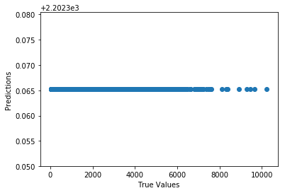

```python
plt.scatter(y_test_num_cat, X_test_num_cat['pred'])
plt.xlabel('True Values')
plt.ylabel('Predictions')
```

```python
# define dataframe for submission
model1 = test_num_cat[['Item_Identifier', 'Outlet_Identifier']]
model1['Item_Outlet_Sales'] = mean_sales

# export submission file
#model1.to_csv('/Users/shusasaki/Documents/data_science_projects/datasets/MartSales data/final_models/model1.csv', index=False)

model1.head(10)
```

|  | Item_Identifier | Outlet_Identifier | Item_Outlet_Sales |
| --- | --- | --- | --- |
| 8523 | FDW58 | OUT049 | 2202.365231 |
| 8524 | FDW14 | OUT017 | 2202.365231 |
| 8525 | NCN55 | OUT010 | 2202.365231 |
| 8526 | FDQ58 | OUT017 | 2202.365231 |
| 8527 | FDY38 | OUT027 | 2202.365231 |
| 8528 | FDH56 | OUT046 | 2202.365231 |
| 8529 | FDL48 | OUT018 | 2202.365231 |
| 8530 | FDC48 | OUT027 | 2202.365231 |
| 8531 | FDN33 | OUT045 | 2202.365231 |
| 8532 | FDA36 | OUT017 | 2202.365231 |

```python
# reinitialise the data
X_train_num_cat, X_test_num_cat, y_train_num_cat, y_test_num_cat = train_test_split(train_num_cat.loc[:, train_num_cat.columns != 'Item_Outlet_Sales'], train_num_cat['Item_Outlet_Sales'], test_size=0.2, random_state=42)
```

### Average Sales by Item_Type_Category

```python
# pivot table with values Item_Outlet_Sales and index Item_Type_Category
X_train_num_cat['Item_Outlet_Sales'] = y_train_num_cat
item_category_sales_table = X_train_num_cat.pivot_table(values='Item_Outlet_Sales', index='Item_Type_Category')
item_category_sales_table
```

| Item_Type_Category | Item_Outlet_Sales |
| --- | --- |
| 0 | 2022.430537 |
| 1 | 2237.307754 |
| 2 | 2159.187339 |

```python
# define function that returns the mean values
def find_sales_means(x):
    return item_category_sales_table.loc[x]
```

```
RMSE: 1651
```

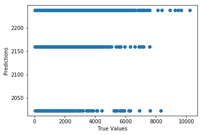

```python
# evaluate model
X_test_num_cat['pred'] = X_test_num_cat['Item_Type_Category'].apply(find_sales_means)
print('RMSE: %.4g' %np.sqrt(mean_squared_error(y_test_num_cat.values, X_test_num_cat['pred'].values)))

plt.scatter(y_test_num_cat, X_test_num_cat['pred'])
plt.xlabel('True Values')
plt.ylabel('Predictions')
```

```python
# define submision model
model2 = test_num_cat[['Item_Identifier', 'Outlet_Identifier', 'Item_Type_Category']]
model2['Item_Outlet_Sales'] = model2['Item_Type_Category'].apply(find_sales_means)
model2 = model2.drop('Item_Type_Category', axis=1)

# export submission file
#model2.to_csv('/Users/shusasaki/Documents/data_science_projects/datasets/MartSales data/final_models/model2.csv', index=False)

model2.head(10)
```

|  | Item_Identifier | Outlet_Identifier | Item_Outlet_Sales |
| --- | --- | --- | --- |
| 8523 | FDW58 | OUT049 | 2237.307754 |
| 8524 | FDW14 | OUT017 | 2237.307754 |
| 8525 | NCN55 | OUT010 | 2159.187339 |
| 8526 | FDQ58 | OUT017 | 2237.307754 |
| 8527 | FDY38 | OUT027 | 2237.307754 |
| 8528 | FDH56 | OUT046 | 2237.307754 |
| 8529 | FDL48 | OUT018 | 2237.307754 |
| 8530 | FDC48 | OUT027 | 2237.307754 |
| 8531 | FDN33 | OUT045 | 2237.307754 |
| 8532 | FDA36 | OUT017 | 2237.307754 |

```python
# reinitialise the data
X_train_num_cat, X_test_num_cat, y_train_num_cat, y_test_num_cat = train_test_split(train_num_cat.loc[:, train_num_cat.columns != 'Item_Outlet_Sales'], train_num_cat['Item_Outlet_Sales'], test_size=0.2, random_state=42)
```

### Average Sales by Product_Type_Category in Particular Outlet_Type

```python
# pivot table with values Item_Outlet_Sales and index Item_Type_Category and Outlet_Category
X_train_num_cat['Item_Outlet_Sales'] = y_train_num_cat
item_outlet_sales_table = X_train_num_cat.pivot_table(values='Item_Outlet_Sales',
                                            index='Item_Type_Category',
                                            columns='Outlet_Type')
item_outlet_sales_table
```

| Outlet_Type Item_Type_Category | 0 | 1 | 2 | 3 |
| --- | --- | --- | --- | --- |
| 0 | 308.407437 | 2148.264504 | 1915.547572 | 3340.198538 |
| 1 | 344.858118 | 2361.702345 | 2061.157693 | 3767.855604 |
| 2 | 361.037616 | 2337.223838 | 2012.974133 | 3477.177489 |

```python
# define function that returns the mean values
def find_sales_means(x):
    return item_outlet_sales_table.loc[x['Item_Type_Category'], x['Outlet_Type']]
```

```
RMSE: 1417
```

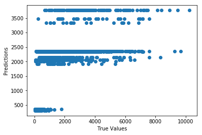

```python
# eval model
# evaluate model
X_test_num_cat['pred'] = X_test_num_cat.apply(find_sales_means, axis=1)
print('RMSE: %.4g' %np.sqrt(mean_squared_error(y_test_num_cat.values, X_test_num_cat['pred'].values)))

plt.scatter(y_test_num_cat, X_test_num_cat['pred'])
plt.xlabel('True Values')
plt.ylabel('Predictions')
```

```python
# define submission file
model3 = test_num_cat[['Item_Identifier', 'Outlet_Identifier',
               'Item_Type_Category', 'Outlet_Type']]

model3['Item_Outlet_Sales'] = model3.apply(find_sales_means, axis=1)
model3 = model3.drop(['Item_Type_Category', 'Outlet_Type'], axis=1)

# export submission file
#model3.to_csv('/Users/shusasaki/Documents/data_science_projects/datasets/MartSales data/final_models/model3.csv', index=False)

model3.head(10)
```

|  | Item_Identifier | Outlet_Identifier | Item_Outlet_Sales |
| --- | --- | --- | --- |
| 8523 | FDW58 | OUT049 | 2361.702345 |
| 8524 | FDW14 | OUT017 | 2361.702345 |
| 8525 | NCN55 | OUT010 | 361.037616 |
| 8526 | FDQ58 | OUT017 | 2361.702345 |
| 8527 | FDY38 | OUT027 | 3767.855604 |
| 8528 | FDH56 | OUT046 | 2361.702345 |
| 8529 | FDL48 | OUT018 | 2061.157693 |
| 8530 | FDC48 | OUT027 | 3767.855604 |
| 8531 | FDN33 | OUT045 | 2361.702345 |
| 8532 | FDA36 | OUT017 | 2361.702345 |

```python
# reinitialise the data
X_train_num_cat, X_test_num_cat, y_train_num_cat, y_test_num_cat = train_test_split(train_num_cat.loc[:, train_num_cat.columns != 'Item_Outlet_Sales'], train_num_cat['Item_Outlet_Sales'], test_size=0.2, random_state=42)
```